# A rodent herbivore reduces its predation risk through ecosystem engineering - ScienceDirect

## Cited By (6)

## Figures (5)

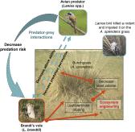

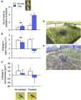

## Extras (2)

1. Document S1. Figures S1–S4, Tables S1–S3, and supplemental references
2. Document S2. Article plus supplemental information

[figure not shown]

## Current Biology

[Volume 32, Issue 8](https://www.sciencedirect.com/journal/current-biology/vol/32/issue/8), 25 April 2022, Pages 1869-1874.e4

# Report A rodent herbivore reduces its predation risk through ecosystem engineering

Referred to by

[Ecology: Voles engineer safe spaces](https://www.sciencedirect.com/science/article/pii/S0960982222004304)

Current Biology, Volume 32, Issue 8, 25 April 2022, Pages R365-R367

Christopher R. Dickman

## Highlights

**•**

Voles modified habitat structure by destroying a large, unpalatable bunchgrass

**•**

Damage activities of voles decreased the plant volume of the bunchgrasses

**•**

Vole damage activities were enhanced at the presence of the predatory birds

**•**

Habitat modifications by voles reduced predation risk and increased vole survival

## Summary

Predator-prey interactions are ubiquitous and powerful forces that structure ecological communities.1, 2, 3 Habitat complexity has been shown to be particularly important in regulating the strength of predator-prey interactions.4, 5, 6 While it is well established that changes in habitat structure can alter the efficacy of predatory and anti-predatory behaviors,7, 8, 9 little is known about the consequences of engineering activity by prey species who modify the external environment to reduce their own [predation risk](https://www.sciencedirect.com/topics/biochemistry-genetics-and-molecular-biology/predation-risk). Using field surveys and manipulative experiments, we evaluated how habitat modification by Brandt’s voles (*Lasiopodomys brandtii*) influences predation risk from a principal avian predator (shrike; *[Lanius](https://www.sciencedirect.com/topics/agricultural-and-biological-sciences/lanius)* spp.) in a steppe grassland, located in Inner Mongolia, China. We found that voles actively modify habitat structure by cutting down a large, unpalatable bunchgrass species (*Achnatherum splendens*) in the presence of shrikes, a behavior that disappeared when these avian predators were excluded experimentally. The damage activities of these voless dramatically decreased the volume of unpalatable grasses, which in turn reduced visitations by shrikes and thus mortality rates. Our study shows that herbivorous prey that act as [ecosystem engineers](https://www.sciencedirect.com/topics/agricultural-and-biological-sciences/ecosystem-engineers) can directly reduce their own predation risk by modifying habitat structure. Given the ubiquity of predation risks faced by consumers, and the likely ability of many consumers to alter the habitat structure in which they live, the interplay between predation risk and ecosystem engineering may be an important but unappreciated mechanism at play in natural communities.

## Graphical abstract

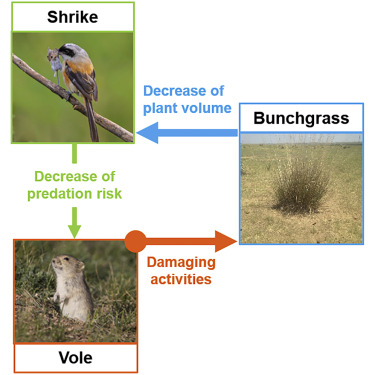

## Keywords

habitat structure

predation risk

predator-prey interactions

trait-mediated indirect effects

Allee effect

voles

predator pit

avian predator

small mammal

ecosystem engineer

## Data and code availability

The datasets that support these findings are deposited at Dryad Digital Repository: https://doi.org/10.5061/dryad.cvdncjt57.<sup>10</sup>

- 2023, iScience

- 2022, Journal of Arid Environments

- 2022, Journal of Human Evolution

- 2022, Microbiome

- 2022, SSRN

- 2022, Behavioral Ecology and Sociobiology

Lead contact

[View full text](https://www.sciencedirect.com/science/article/pii/S096098222200344X)

© 2022 Elsevier Inc.

  Nikou Fotouhi, …, Edward E. Farmer

- Current Biology, Volume 32, Issue 10, 2022, pp. 2334-2340.e3

  Christoph Guschlbauer, …, Ansgar Büschges

- Current Biology, Volume 32, Issue 8, 2022, pp. R354-R355

  Shichang Zhang, …, Daiqin Li

Citations

Captures

- Readers: 23

Mentions

Social Media